# Processing IDA MS<sup>2</sup> data - Basic Functions

Michael

24th of June 2018

## Basic processing of DDA MS<sup>2</sup> data with XCMS

Metabolite identification is usually achieved by comparing MS2 spectra against reference spectra. Such MS2 data can be generated using data dependent acquistion. For further processing it is important to link the MS<sup>1</sup> features and collected MS<sup>2</sup> spectra. Here simply means to isolate MS2 spectra belonging to a certain chromatographic peak are presented.

## Setup of XCMS

XCMS3 is able to use multiple cores (e.g. when working on multiple files). If required a parallel backend can be registered.

```r
#load required library
library(xcms)
library(ggplot2)

#set number of cores
noOfCores <- 4

## Use socket based parallel processing on Windows systems
if (.Platform$OS.type == "unix") {
  register(bpstart(MulticoreParam(noOfCores)))
} else {
  register(bpstart(SnowParam(noOfCores)))
}
```

## Read MS data

The example file contains an RP-LC-MS run of Mix 1 taken from the Agilent Pesticide Reference mix measured on a Sciex TripleTof 6600 using SWATH data acquisition mode. First we plot a base peak chromatogram to get an overview on the chromatogram.

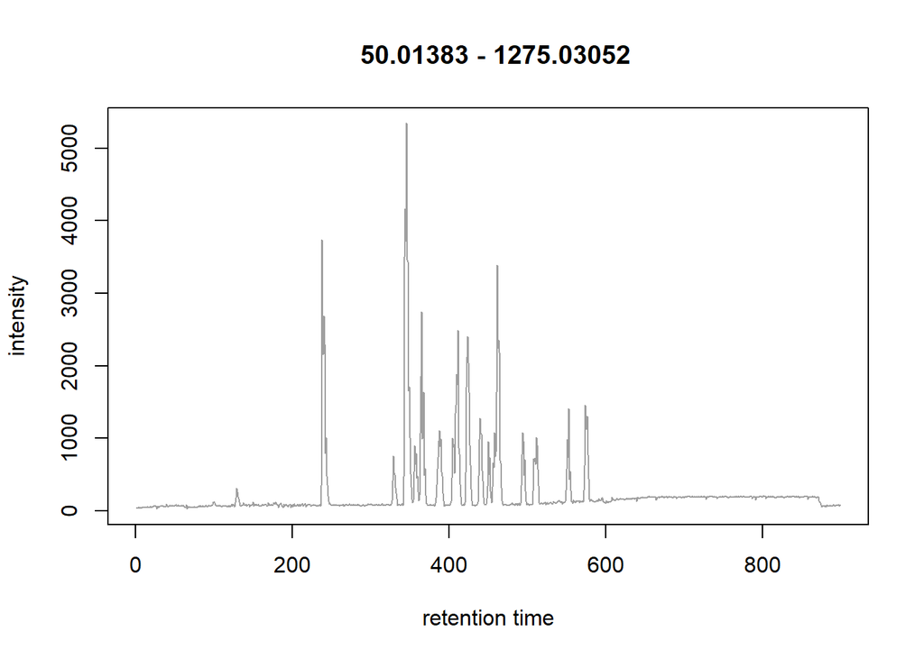

```r
## MS1 and MS2 data and file has to be read only once.
xrms <- readMSData("data\\PestMix1_SWATH.mzML", mode = "onDisk", centroided = TRUE)

#plot BPC
bpis <- chromatogram(xrms, aggregationFun = "max")
plot(bpis)
```

## Splitting of data into different MS level and SWATH pockets

To further process the data it has to be splitted into the different MS levels. This is achieved by the `filterMsLevel()` function. The MS<sup>2</sup> is further split according to the precursors (in total 8 unique representing the 8 SWATH pockets). A list of `OnDiskMSnExp` objects is returned by the split function.

```r
# filter out the MS1 & MS2 level
xrms_ms1 <- filterMsLevel(xrms, msLevel = 1)
xrms_ms2 <- filterMsLevel(xrms, msLevel = 2)

# split MS2 data into SWATH pockets
# Use the fData method to access the "feature data" (i.e. the mzML header)
precursors <- fData(xrms_ms2)$precursorMZ
unique(precursors)
```

```
## [1] 163.75 208.95 244.05 270.85 299.10 329.80 367.35 601.85
```

```r
#split according to different SWATH windows
xrms_ms2_swath <- split(xrms_ms2, f = as.integer(precursors))
```

Optional: Plotting of individual BPCs.

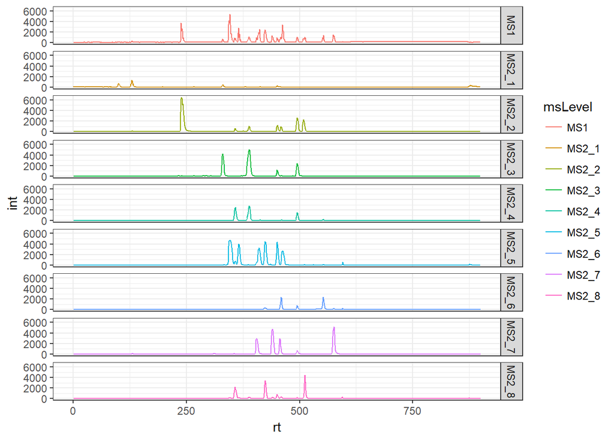

```r
# create BPC for MS1 level
bpis <- chromatogram(xrms_ms1, aggregationFun = "max", msLevel = 1)

# get data in BPC
bpcDf <- data.frame(rt = bpis[[1]]@rtime,
                    int = bpis[[1]]@intensity,
                    msLevel = "MS1")

# generate BPC for each SWATH windows and add
for(i in 1:length(xrms_ms2_swath)) {

  bpis <- chromatogram(xrms_ms2_swath[[i]], aggregationFun = "max", msLevel = 2)

  bpcDf_clipboard <- data.frame(rt = bpis[[1]]@rtime,
                                int = bpis[[1]]@intensity,
                                msLevel = paste0("MS2_", i))

  # add to data frame
  bpcDf <- rbind.data.frame(bpcDf, bpcDf_clipboard)
}

# create plot with ggplots
ggplot(bpcDf, aes(x = rt, y = int, colour = msLevel)) + geom_line() + facet_grid(msLevel ~ .) + theme_bw()
```

## Working with SWATH data

Working with SWATH data requires some additional functions borrowed from the `swathR` package, currently under development (https://github.com/michaelwitting/swathR). These functions perform correlation of EICs of the MS<sup>1</sup> trace and potential MS<sup>2</sup> fragment candidates. The functions can be found in the functions folder and are loaded via `source()`.

```r
source("functions\\eicFunctions.R")
source("functions\\fragmentCandSearch.R")
source("functions\\plottingFunctions.R")
source("functions\\reconSpectrum.R")
source("functions\\spectraFunctions.R")
source("functions\\utils.R")
```

Next chromatographic peak detection is performed on the MS<sup>1</sup> and MS<sup>2</sup> level. Different settings can be used for the different MS level. The `findChromPeaks` function can be applied to the list of `OnDiskMsnExp` via the `lapply()` function.

```r
## Set parameter for Centwave peak detection
ms1cwp <- CentWaveParam(snthresh = 5, noise = 100, ppm = 10, peakwidth = c(3,30))
ms2cwp <- CentWaveParam(snthresh = 3, noise = 10, ppm = 10, peakwidth = c(3,30))

# find peaks in MS1 level
ms1data <- findChromPeaks(xrms_ms1, param = ms1cwp, msLevel = 1)
```

```
## Detecting mass traces at 10 ppm ... OK
## Detecting chromatographic peaks in 69 regions of interest ... OK: 66 found.
```

```r
# find peaks in MS2 level
# Peak detection on all; explicitely tell findChromPeaks to run on MS2
ms2data <- lapply(xrms_ms2_swath, FUN = findChromPeaks, param = ms2cwp, msLevel = 2)
```

```
## Detecting mass traces at 10 ppm ... OK
## Detecting chromatographic peaks in 5 regions of interest ... OK: 8 found.
## Detecting mass traces at 10 ppm ... OK
## Detecting chromatographic peaks in 38 regions of interest ... OK: 40 found.
## Detecting mass traces at 10 ppm ... OK
## Detecting chromatographic peaks in 32 regions of interest ... OK: 33 found.
## Detecting mass traces at 10 ppm ... OK
## Detecting chromatographic peaks in 16 regions of interest ... OK: 14 found.
## Detecting mass traces at 10 ppm ... OK
## Detecting chromatographic peaks in 105 regions of interest ... OK: 109 found.
## Detecting mass traces at 10 ppm ... OK
## Detecting chromatographic peaks in 25 regions of interest ... OK: 23 found.
## Detecting mass traces at 10 ppm ... OK
## Detecting chromatographic peaks in 66 regions of interest ... OK: 64 found.
## Detecting mass traces at 10 ppm ... OK
## Detecting chromatographic peaks in 35 regions of interest ... OK: 33 found.
```

Afterwards, chromatogrpahic peaks from the MS<sup>1</sup> level are retrieved. Fluopicolide is used again as example.

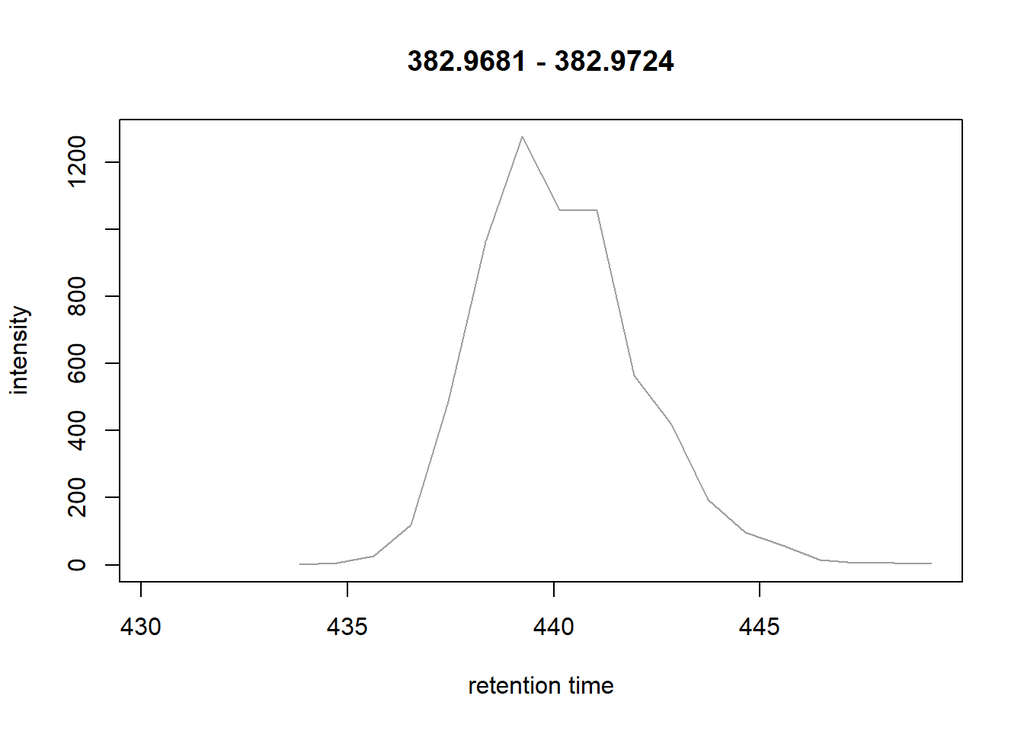

```r
# get all MS1 peaks
ms1chromPeaks <- chromPeaks(ms1data)

# Fluopicolide, exact mass = 381.965430576, [M+H]+ = 382.972706
eic <- chromatogram(xrms_ms1, aggregationFun = "max", mz = c(382.96, 382.98), rt = c(430,450))
plot(eic)
```

```r
# isolate Fluopicolide
chromPeak <- ms1chromPeaks[41,]
```

For reconstruction of a MS<sup>2</sup> spectrum from the SWATH data chromatographic peaks from the fitting SWATH pocket are required. The `searchMultiplePIcandidates()` retrieves all potential fragment candidates within a give retention time window, in this case 5 seconds.

```r
# get peaks in fitting SWATH pocket
ms2chromPeaks <- chromPeaks(ms2data[[7]])

# get fragment candidates
fragCand <- searchMultiplePIcandidates(chromPeak, ms2chromPeaks, 5)
```

If one or more fitting candidates are found correlation of the MS<sup>1</sup> EIC the EICs from MS<sup>2</sup> candidates is performed. If the correlation is above a certain treshold a peak is retained as fragment, otherwise it is discarded.

```
## Chromatograms with 22 rows and 1 column
##       PestMix1_SWATH.mzML
##            <Chromatogram>
## [1,]           length: 17
## [2,]           length: 17
## ...                  ...
## [21,]          length: 16
## [22,]          length: 17
## phenoData with 1 variables
## featureData with 5 variables
```

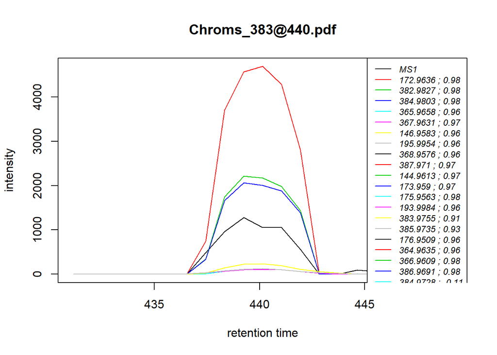

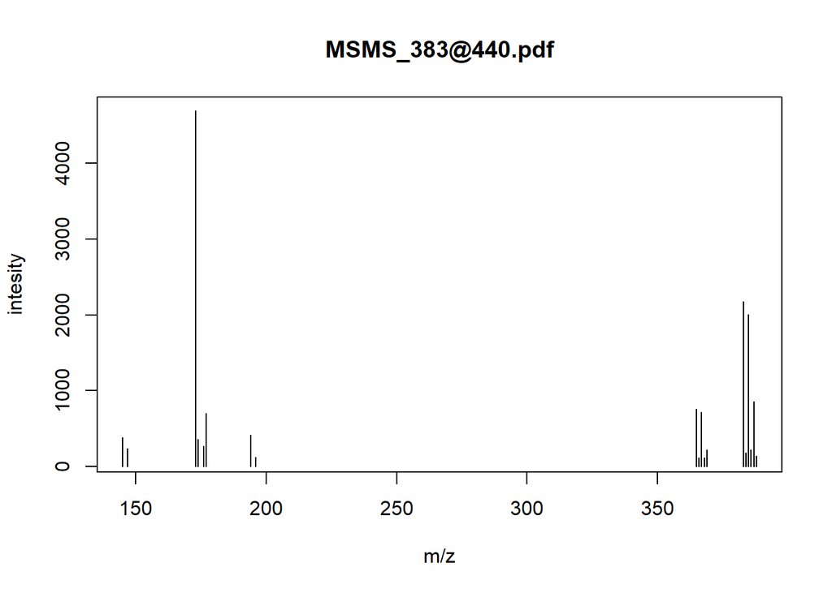

```r
if(nrow(fragCand) > 0) {

  # get EICs for MS1 precursor and MS2 fragment candidates
  ms1df <- getEics(ms1data, chromPeak, rtwindow = 5, msLevel = 1)
  ms2df <- getEics(ms2data[[7]], fragCand, rtwindow = 5, msLevel = 2)

  # Align MS2 data with MS1
  ms2dfCor <- alignMsLevel(ms1df, ms2df)

  # correlate MS1 and MS2
  corValues <- correlateMsLevel(ms1df, ms2dfCor)

  # plot EICs
  plotCandEICs(ms1df, ms2dfCor, chromPeak, corValues)

  # reconstruct MS2 spectrum
  ms2spectrum <- reconSpectrum(chromPeak, ms2dfCor, corValues)
  plotSpectrum(ms2spectrum, chromPeak)

}
```

Optional: A Spectrum2 object from the MSnbase package can be generated from the obtained data. With this, functions availabe in MSnbase for spectral handling can be used, e.g. comparison of spectra using the `compareSpectra()` function.

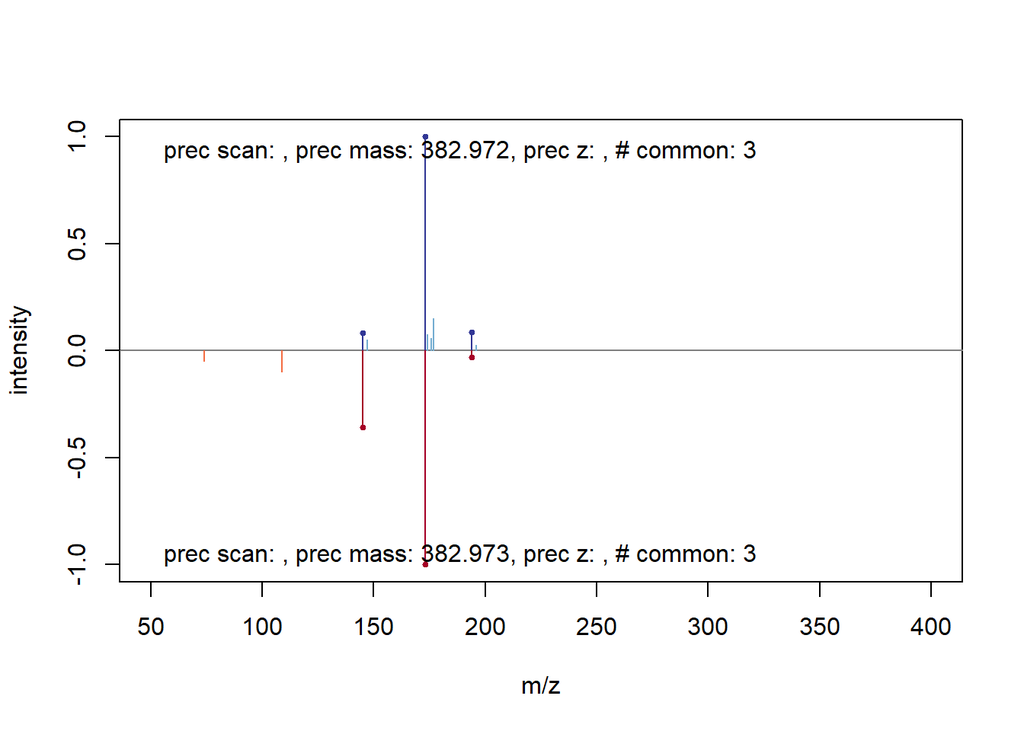

```r
# make Spectrum2 object
ms2spectrumMSnbase <- new("Spectrum2",
                          precursorMz = chromPeak[1],
                          rt = chromPeak[4],
                          mz = ms2spectrum$mz,
                          intensity = ms2spectrum$intensity,
                          centroided = TRUE)

#trim to same mass region (remove precursor peaks)
ms2spectrumMSnbase <- trimMz(ms2spectrumMSnbase, mzlim = c(50,350))

#example spectrum (taken from Metlin MID 72270, ESI-Q-ToF)
librarySpectrum <- new("Spectrum2",
                       precursorMz = 382.9727,
                       mz = c(193.9949, 172.9555, 144.9603, 108.9841, 74.0161),
                       intensity = c(3, 100, 36, 10, 5),
                       centroided = TRUE)

# make mirror plot of two spectra
plot(ms2spectrumMSnbase, librarySpectrum, xlim = c(50,400))
```

```r
# calculate dot product
compareSpectra(ms2spectrumMSnbase, librarySpectrum, binSize = 0.05, fun = "dotproduct")
```

```
## [1] 0.9424352
```